# IPTW

# Balance tables and balance plots for each imputed dataset

Dataset number 1

|  | tx.mn | ct.mn | std.eff.sz | p | tx.mn | ct.mn | std.eff.sz | p |
| --- | --- | --- | --- | --- | --- | --- | --- | --- |
| age | 63.36 | 60.21 | 0.27 | 0.02 | 63.06 | 61.27 | 0.16 | 0.24 |
| age: | 0.00 | 0.02 | NA | 0.00 | 0.00 | 0.03 | NA | 0.00 |
| sex:female | 0.40 | 0.33 | 0.16 | 0.17 | 0.37 | 0.32 | 0.11 | 0.39 |
| sex:male | 0.60 | 0.67 | -0.16 | NA | 0.63 | 0.68 | -0.11 | NA |
| CEA | 37.55 | 66.23 | -0.16 | 0.27 | 35.06 | 64.67 | -0.18 | 0.26 |
| CEA: | 0.28 | 0.33 | -0.10 | 0.41 | 0.29 | 0.35 | -0.13 | 0.35 |
| ismajor | 0.27 | 0.69 | -0.84 | 0.00 | 0.40 | 0.57 | -0.33 | 0.02 |
| difloc | 0.34 | 0.56 | -0.43 | 0.00 | 0.41 | 0.48 | -0.13 | 0.35 |
| isbilateral | 0.11 | 0.27 | -0.41 | 0.00 | 0.13 | 0.23 | -0.26 | 0.06 |
| lesionmaxdiameter | 32.32 | 41.26 | -0.34 | 0.01 | 34.03 | 38.38 | -0.17 | 0.21 |
| lesionmaxdiameter: | 0.06 | 0.12 | -0.23 | 0.11 | 0.06 | 0.13 | -0.32 | 0.08 |
| lesioncount | 1.50 | 2.24 | -0.53 | 0.00 | 1.62 | 2.01 | -0.28 | 0.04 |
| lesioncount: | 0.06 | 0.12 | -0.23 | 0.11 | 0.06 | 0.13 | -0.32 | 0.08 |
| primarytumourgrade:moderately differentiated | 0.54 | 0.44 | 0.20 | 0.04 | 0.49 | 0.46 | 0.07 | 0.16 |
| primarytumourgrade:poorly differentiated | 0.17 | 0.12 | 0.15 | NA | 0.19 | 0.11 | 0.21 | NA |
| primarytumourgrade:well differentiated | 0.03 | 0.06 | -0.23 | NA | 0.03 | 0.05 | -0.16 | NA |
| primarytumourgrade: | 0.26 | 0.38 | -0.27 | NA | 0.29 | 0.38 | -0.20 | NA |
| primaryT:2 | 0.23 | 0.12 | 0.26 | 0.10 | 0.22 | 0.11 | 0.26 | 0.14 |
| primaryT:3 | 0.42 | 0.44 | -0.05 | NA | 0.43 | 0.43 | -0.01 | NA |
| primaryT:4 | 0.14 | 0.15 | -0.04 | NA | 0.13 | 0.16 | -0.09 | NA |
| primaryT: | 0.21 | 0.28 | -0.17 | NA | 0.22 | 0.30 | -0.18 | NA |
| primaryN:0 | 0.34 | 0.22 | 0.25 | 0.00 | 0.29 | 0.24 | 0.11 | 0.08 |
| primaryN:1 | 0.22 | 0.38 | -0.40 | NA | 0.27 | 0.35 | -0.18 | NA |
| primaryN:2 | 0.16 | 0.12 | 0.09 | NA | 0.16 | 0.13 | 0.07 | NA |
| primaryN:3 | 0.08 | 0.01 | 0.26 | NA | 0.07 | 0.01 | 0.24 | NA |
| primaryN: | 0.20 | 0.26 | -0.14 | NA | 0.22 | 0.27 | -0.13 | NA |
| year_primary:0 | 0.03 | 0.02 | 0.07 | 0.37 | 0.03 | 0.02 | 0.08 | 0.61 |
| year_primary:1 | 0.42 | 0.33 | 0.20 | NA | 0.42 | 0.35 | 0.13 | NA |
| year_primary:2 | 0.25 | 0.25 | 0.00 | NA | 0.24 | 0.23 | 0.03 | NA |
| year_primary:3 | 0.09 | 0.08 | 0.03 | NA | 0.08 | 0.08 | 0.01 | NA |
| year_primary:4 | 0.04 | 0.06 | -0.08 | NA | 0.04 | 0.06 | -0.08 | NA |
| year_primary:5 | 0.07 | 0.09 | -0.10 | NA | 0.09 | 0.08 | 0.01 | NA |
| year_primary: | 0.10 | 0.17 | -0.26 | NA | 0.09 | 0.18 | -0.28 | NA |
| primarytreatment:no | 0.25 | 0.24 | 0.02 | 0.51 | 0.23 | 0.25 | -0.03 | 0.40 |
| primarytreatment:yes | 0.60 | 0.55 | 0.09 | NA | 0.61 | 0.53 | 0.16 | NA |
| primarytreatment: | 0.16 | 0.21 | -0.14 | NA | 0.16 | 0.22 | -0.18 | NA |

Dataset number 2

|  | tx.mn | ct.mn | std.eff.sz | p | tx.mn | ct.mn | std.eff.sz | p |
| --- | --- | --- | --- | --- | --- | --- | --- | --- |
| age | 63.36 | 60.25 | 0.27 | 0.02 | 62.65 | 61.25 | 0.12 | 0.32 |
| sex:female | 0.40 | 0.33 | 0.16 | 0.17 | 0.39 | 0.31 | 0.16 | 0.19 |
| sex:male | 0.60 | 0.67 | -0.16 | NA | 0.61 | 0.69 | -0.16 | NA |
| CEA | 33.23 | 57.24 | -0.15 | 0.22 | 34.40 | 54.54 | -0.13 | 0.30 |
| ismajor | 0.27 | 0.69 | -0.84 | 0.00 | 0.40 | 0.56 | -0.31 | 0.02 |
| difloc | 0.34 | 0.56 | -0.43 | 0.00 | 0.40 | 0.47 | -0.14 | 0.27 |
| isbilateral | 0.11 | 0.27 | -0.41 | 0.00 | 0.13 | 0.22 | -0.25 | 0.04 |
| lesionmaxdiameter | 32.20 | 40.72 | -0.33 | 0.01 | 33.41 | 38.43 | -0.20 | 0.10 |
| lesioncount | 1.49 | 2.15 | -0.49 | 0.00 | 1.59 | 1.92 | -0.25 | 0.04 |
| primarytumourgrade:moderately differentiated | 0.75 | 0.62 | 0.30 | 0.06 | 0.74 | 0.63 | 0.24 | 0.21 |
| primarytumourgrade:poorly differentiated | 0.20 | 0.29 | -0.23 | NA | 0.21 | 0.29 | -0.20 | NA |
| primarytumourgrade:well differentiated | 0.05 | 0.09 | -0.18 | NA | 0.05 | 0.08 | -0.11 | NA |
| primaryT:2 | 0.27 | 0.18 | 0.21 | 0.14 | 0.27 | 0.16 | 0.23 | 0.08 |
| primaryT:3 | 0.51 | 0.61 | -0.20 | NA | 0.50 | 0.63 | -0.26 | NA |
| primaryT:4 | 0.22 | 0.21 | 0.02 | NA | 0.23 | 0.20 | 0.06 | NA |
| primaryN:0 | 0.44 | 0.34 | 0.21 | 0.00 | 0.42 | 0.33 | 0.18 | 0.01 |
| primaryN:1 | 0.29 | 0.50 | -0.47 | NA | 0.32 | 0.50 | -0.39 | NA |
| primaryN:2 | 0.17 | 0.14 | 0.07 | NA | 0.17 | 0.16 | 0.04 | NA |
| primaryN:3 | 0.10 | 0.01 | 0.28 | NA | 0.09 | 0.02 | 0.26 | NA |
| year_primary:0 | 0.03 | 0.03 | 0.03 | 0.33 | 0.03 | 0.03 | 0.04 | 0.24 |
| year_primary:1 | 0.49 | 0.40 | 0.19 | NA | 0.50 | 0.40 | 0.19 | NA |
| year_primary:2 | 0.26 | 0.30 | -0.08 | NA | 0.25 | 0.29 | -0.09 | NA |
| year_primary:3 | 0.10 | 0.08 | 0.08 | NA | 0.11 | 0.07 | 0.12 | NA |
| year_primary:4 | 0.04 | 0.08 | -0.20 | NA | 0.04 | 0.09 | -0.25 | NA |
| year_primary:5 | 0.07 | 0.12 | -0.19 | NA | 0.07 | 0.12 | -0.20 | NA |
| primarytreatment:no | 0.29 | 0.34 | -0.12 | 0.34 | 0.26 | 0.38 | -0.28 | 0.04 |
| primarytreatment:yes | 0.71 | 0.66 | 0.12 | NA | 0.74 | 0.62 | 0.28 | NA |

Dataset number 3

|  | tx.mn | ct.mn | std.eff.sz | p | tx.mn | ct.mn | std.eff.sz | p |
| --- | --- | --- | --- | --- | --- | --- | --- | --- |
| age | 63.36 | 60.27 | 0.27 | 0.02 | 62.94 | 61.20 | 0.15 | 0.22 |
| sex:female | 0.40 | 0.33 | 0.16 | 0.17 | 0.38 | 0.31 | 0.14 | 0.25 |
| sex:male | 0.60 | 0.67 | -0.16 | NA | 0.62 | 0.69 | -0.14 | NA |
| CEA | 32.78 | 53.11 | -0.14 | 0.26 | 34.57 | 48.31 | -0.10 | 0.45 |
| ismajor | 0.27 | 0.69 | -0.84 | 0.00 | 0.41 | 0.55 | -0.29 | 0.03 |
| difloc | 0.34 | 0.56 | -0.43 | 0.00 | 0.40 | 0.47 | -0.13 | 0.31 |
| isbilateral | 0.11 | 0.27 | -0.41 | 0.00 | 0.13 | 0.22 | -0.24 | 0.08 |
| lesionmaxdiameter | 32.14 | 41.62 | -0.34 | 0.00 | 33.53 | 38.70 | -0.20 | 0.11 |
| lesioncount | 1.52 | 2.15 | -0.45 | 0.00 | 1.64 | 1.93 | -0.21 | 0.10 |
| primarytumourgrade:moderately differentiated | 0.76 | 0.66 | 0.24 | 0.07 | 0.73 | 0.68 | 0.12 | 0.37 |
| primarytumourgrade:poorly differentiated | 0.21 | 0.26 | -0.12 | NA | 0.24 | 0.25 | -0.03 | NA |
| primarytumourgrade:well differentiated | 0.03 | 0.08 | -0.32 | NA | 0.03 | 0.07 | -0.22 | NA |
| primaryT:2 | 0.27 | 0.17 | 0.23 | 0.07 | 0.24 | 0.16 | 0.20 | 0.06 |
| primaryT:3 | 0.56 | 0.58 | -0.05 | NA | 0.59 | 0.57 | 0.05 | NA |
| primaryT:4 | 0.18 | 0.25 | -0.20 | NA | 0.17 | 0.28 | -0.30 | NA |
| primaryN:0 | 0.40 | 0.34 | 0.12 | 0.01 | 0.34 | 0.34 | 0.00 | 0.08 |
| primaryN:1 | 0.34 | 0.49 | -0.32 | NA | 0.42 | 0.48 | -0.10 | NA |
| primaryN:2 | 0.18 | 0.16 | 0.07 | NA | 0.17 | 0.18 | -0.03 | NA |
| primaryN:3 | 0.08 | 0.01 | 0.26 | NA | 0.07 | 0.01 | 0.24 | NA |
| year_primary:0 | 0.04 | 0.02 | 0.10 | 0.89 | 0.04 | 0.02 | 0.08 | 0.98 |
| year_primary:1 | 0.45 | 0.42 | 0.06 | NA | 0.46 | 0.44 | 0.03 | NA |
| year_primary:2 | 0.27 | 0.28 | -0.02 | NA | 0.25 | 0.28 | -0.06 | NA |
| year_primary:3 | 0.09 | 0.09 | -0.02 | NA | 0.09 | 0.09 | -0.02 | NA |
| year_primary:4 | 0.06 | 0.06 | -0.05 | NA | 0.06 | 0.06 | 0.00 | NA |
| year_primary:5 | 0.09 | 0.12 | -0.09 | NA | 0.11 | 0.11 | 0.00 | NA |
| primarytreatment:no | 0.31 | 0.30 | 0.01 | 0.94 | 0.28 | 0.33 | -0.10 | 0.46 |
| primarytreatment:yes | 0.69 | 0.70 | -0.01 | NA | 0.72 | 0.67 | 0.10 | NA |

Dataset number 4

|  | tx.mn | ct.mn | std.eff.sz | p | tx.mn | ct.mn | std.eff.sz | p |
| --- | --- | --- | --- | --- | --- | --- | --- | --- |
| age | 63.36 | 60.38 | 0.26 | 0.03 | 63.07 | 61.30 | 0.16 | 0.23 |
| sex:female | 0.40 | 0.33 | 0.16 | 0.17 | 0.38 | 0.32 | 0.13 | 0.30 |
| sex:male | 0.60 | 0.67 | -0.16 | NA | 0.62 | 0.68 | -0.13 | NA |
| CEA | 34.75 | 52.60 | -0.12 | 0.33 | 34.34 | 50.52 | -0.12 | 0.35 |
| ismajor | 0.27 | 0.69 | -0.84 | 0.00 | 0.41 | 0.55 | -0.29 | 0.03 |
| difloc | 0.34 | 0.56 | -0.43 | 0.00 | 0.40 | 0.46 | -0.14 | 0.30 |
| isbilateral | 0.11 | 0.27 | -0.41 | 0.00 | 0.13 | 0.22 | -0.24 | 0.06 |
| lesionmaxdiameter | 31.95 | 40.04 | -0.31 | 0.01 | 33.62 | 36.83 | -0.13 | 0.29 |
| lesioncount | 1.49 | 2.13 | -0.47 | 0.00 | 1.60 | 1.89 | -0.22 | 0.07 |
| primarytumourgrade:moderately differentiated | 0.77 | 0.64 | 0.33 | 0.01 | 0.76 | 0.65 | 0.25 | 0.09 |
| primarytumourgrade:poorly differentiated | 0.20 | 0.26 | -0.16 | NA | 0.22 | 0.27 | -0.13 | NA |
| primarytumourgrade:well differentiated | 0.03 | 0.10 | -0.45 | NA | 0.03 | 0.08 | -0.33 | NA |
| primaryT:2 | 0.28 | 0.20 | 0.17 | 0.29 | 0.27 | 0.18 | 0.19 | 0.27 |
| primaryT:3 | 0.52 | 0.59 | -0.15 | NA | 0.55 | 0.62 | -0.14 | NA |
| primaryT:4 | 0.20 | 0.20 | -0.01 | NA | 0.18 | 0.20 | -0.04 | NA |
| primaryN:0 | 0.42 | 0.31 | 0.23 | 0.00 | 0.37 | 0.32 | 0.10 | 0.12 |
| primaryN:1 | 0.29 | 0.51 | -0.48 | NA | 0.36 | 0.48 | -0.26 | NA |
| primaryN:2 | 0.20 | 0.17 | 0.08 | NA | 0.19 | 0.17 | 0.04 | NA |
| primaryN:3 | 0.09 | 0.01 | 0.26 | NA | 0.08 | 0.02 | 0.21 | NA |
| year_primary:0 | 0.03 | 0.02 | 0.07 | 0.70 | 0.03 | 0.02 | 0.08 | 0.71 |
| year_primary:1 | 0.44 | 0.40 | 0.09 | NA | 0.43 | 0.42 | 0.02 | NA |
| year_primary:2 | 0.29 | 0.28 | 0.01 | NA | 0.30 | 0.27 | 0.07 | NA |
| year_primary:3 | 0.10 | 0.10 | 0.00 | NA | 0.10 | 0.10 | 0.03 | NA |
| year_primary:4 | 0.06 | 0.06 | -0.05 | NA | 0.05 | 0.07 | -0.08 | NA |
| year_primary:5 | 0.08 | 0.13 | -0.21 | NA | 0.08 | 0.13 | -0.20 | NA |
| primarytreatment:no | 0.28 | 0.29 | -0.02 | 0.87 | 0.26 | 0.31 | -0.10 | 0.43 |
| primarytreatment:yes | 0.72 | 0.71 | 0.02 | NA | 0.74 | 0.69 | 0.10 | NA |

Dataset number 5

|  | tx.mn | ct.mn | std.eff.sz | p | tx.mn | ct.mn | std.eff.sz | p |
| --- | --- | --- | --- | --- | --- | --- | --- | --- |
| age | 63.36 | 60.22 | 0.27 | 0.02 | 62.85 | 61.17 | 0.15 | 0.25 |
| sex:female | 0.40 | 0.33 | 0.16 | 0.17 | 0.39 | 0.32 | 0.16 | 0.20 |
| sex:male | 0.60 | 0.67 | -0.16 | NA | 0.61 | 0.68 | -0.16 | NA |
| CEA | 31.28 | 59.45 | -0.18 | 0.15 | 29.40 | 55.76 | -0.17 | 0.16 |
| ismajor | 0.27 | 0.69 | -0.84 | 0.00 | 0.40 | 0.55 | -0.31 | 0.02 |
| difloc | 0.34 | 0.56 | -0.43 | 0.00 | 0.41 | 0.48 | -0.13 | 0.33 |
| isbilateral | 0.11 | 0.27 | -0.41 | 0.00 | 0.13 | 0.22 | -0.22 | 0.08 |
| lesionmaxdiameter | 33.79 | 41.55 | -0.28 | 0.02 | 35.28 | 39.09 | -0.14 | 0.24 |
| lesioncount | 1.48 | 2.14 | -0.48 | 0.00 | 1.62 | 1.89 | -0.19 | 0.14 |
| primarytumourgrade:moderately differentiated | 0.77 | 0.67 | 0.24 | 0.13 | 0.76 | 0.69 | 0.16 | 0.52 |
| primarytumourgrade:poorly differentiated | 0.19 | 0.25 | -0.16 | NA | 0.19 | 0.25 | -0.15 | NA |
| primarytumourgrade:well differentiated | 0.03 | 0.07 | -0.21 | NA | 0.05 | 0.06 | -0.04 | NA |
| primaryT:2 | 0.27 | 0.20 | 0.14 | 0.44 | 0.25 | 0.18 | 0.18 | 0.32 |
| primaryT:3 | 0.56 | 0.59 | -0.08 | NA | 0.57 | 0.60 | -0.07 | NA |
| primaryT:4 | 0.18 | 0.20 | -0.06 | NA | 0.18 | 0.22 | -0.11 | NA |
| primaryN:0 | 0.45 | 0.33 | 0.24 | 0.00 | 0.43 | 0.34 | 0.17 | 0.00 |
| primaryN:1 | 0.27 | 0.50 | -0.53 | NA | 0.29 | 0.48 | -0.41 | NA |
| primaryN:2 | 0.19 | 0.16 | 0.08 | NA | 0.18 | 0.17 | 0.05 | NA |
| primaryN:3 | 0.09 | 0.01 | 0.29 | NA | 0.09 | 0.01 | 0.29 | NA |
| year_primary:0 | 0.03 | 0.02 | 0.07 | 0.82 | 0.03 | 0.02 | 0.06 | 0.90 |
| year_primary:1 | 0.46 | 0.40 | 0.12 | NA | 0.45 | 0.42 | 0.06 | NA |
| year_primary:2 | 0.26 | 0.28 | -0.05 | NA | 0.26 | 0.27 | -0.03 | NA |
| year_primary:3 | 0.10 | 0.12 | -0.07 | NA | 0.11 | 0.10 | 0.02 | NA |
| year_primary:4 | 0.04 | 0.06 | -0.12 | NA | 0.04 | 0.07 | -0.16 | NA |
| year_primary:5 | 0.11 | 0.12 | -0.02 | NA | 0.12 | 0.12 | -0.01 | NA |
| primarytreatment:no | 0.32 | 0.30 | 0.02 | 0.85 | 0.32 | 0.34 | -0.06 | 0.66 |
| primarytreatment:yes | 0.68 | 0.70 | -0.02 | NA | 0.68 | 0.66 | 0.06 | NA |

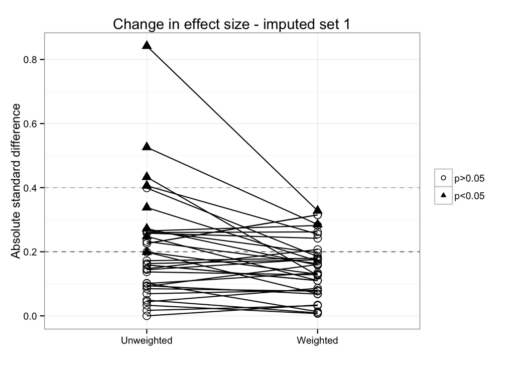

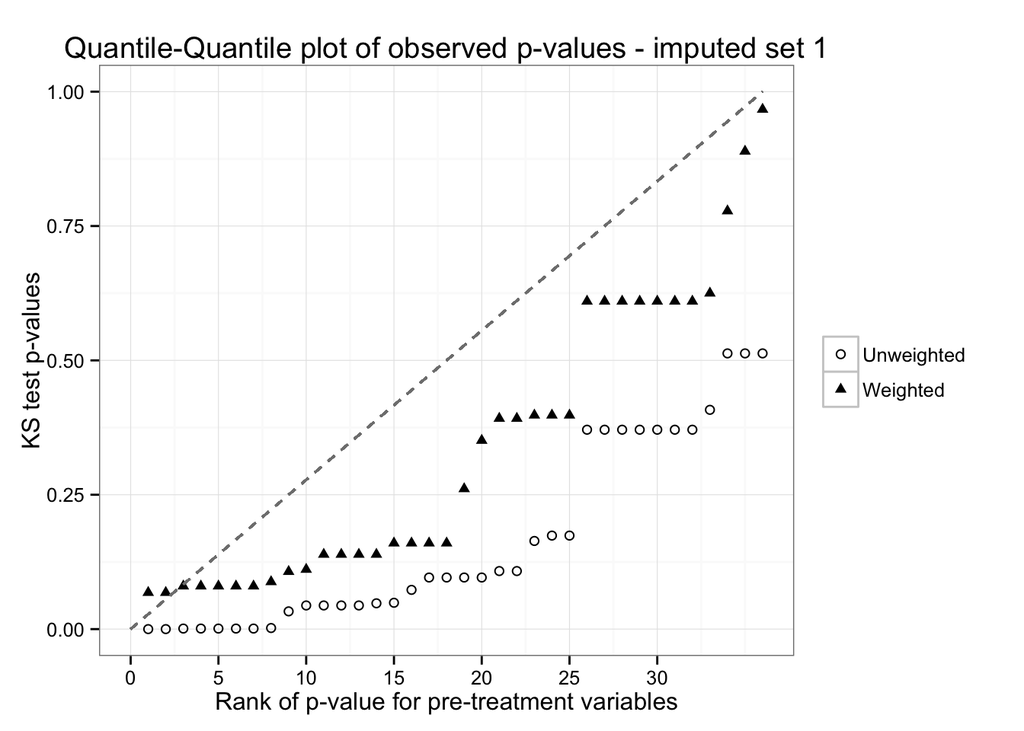

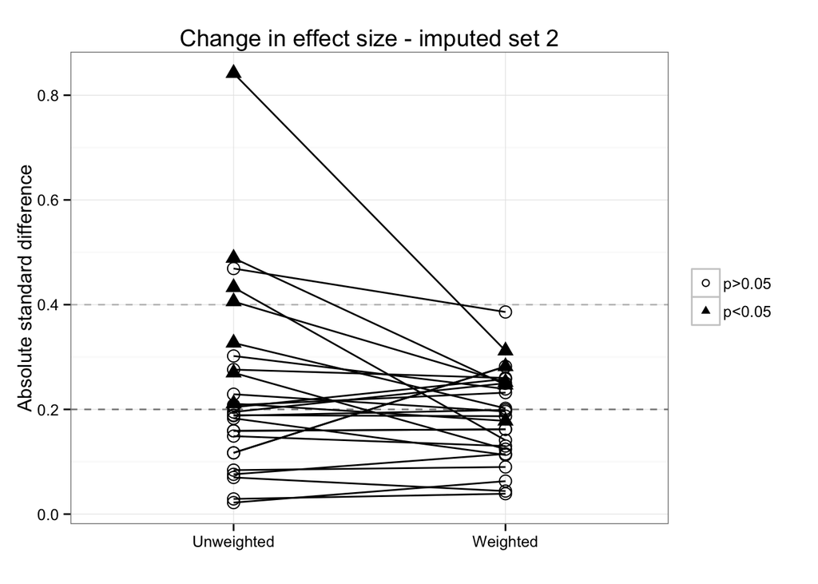

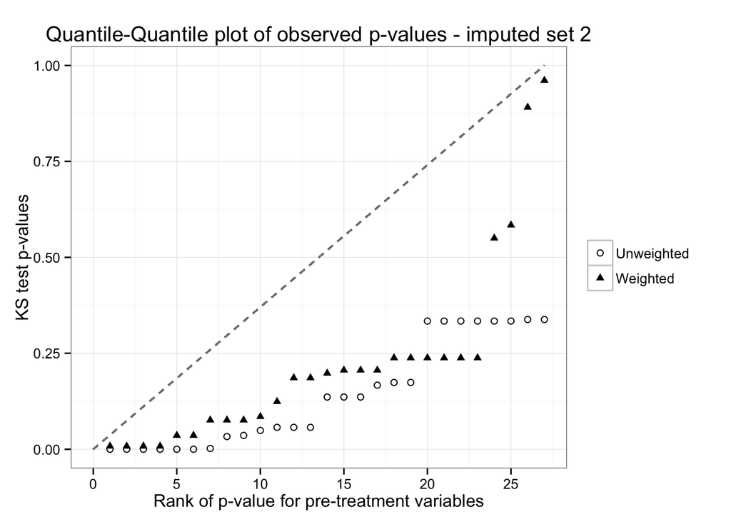

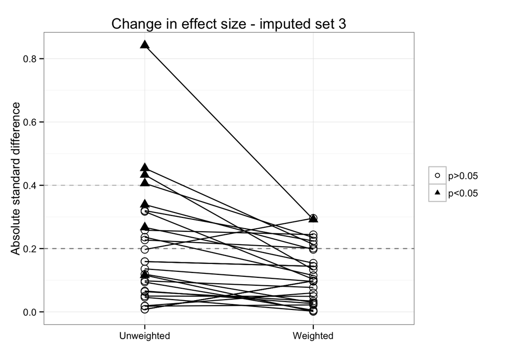

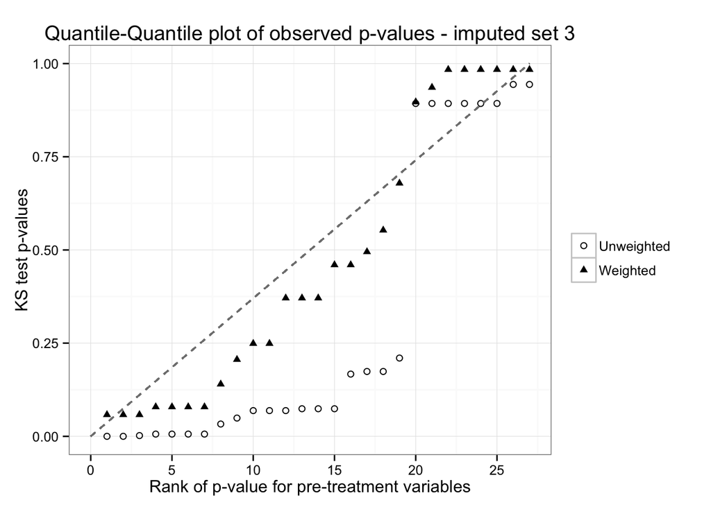

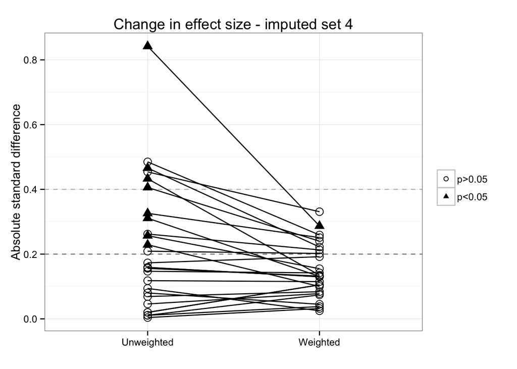

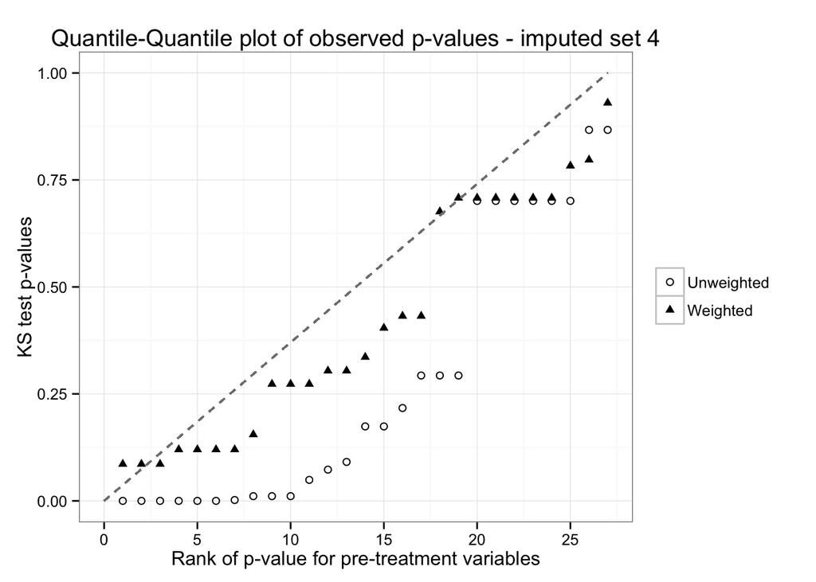

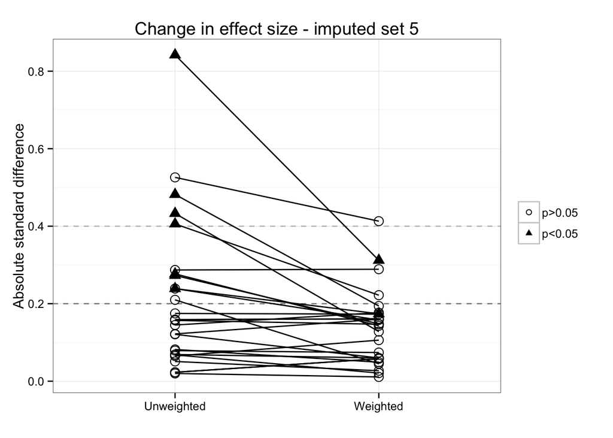

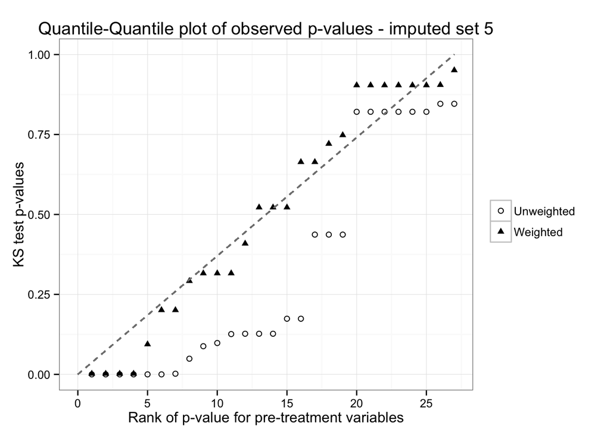

# Generate an “imputationList”" object from the data

This will allow the use of mitools to combine the results of analyses from the survey and other packages and account for the imputations using Rubin’s rules. At this stage, we also construct some new compound variables.

```r
mit <- impdata[2:6]

for (i in 1:5) {
  mit[[i]] %>% group_by(id_patients) %>%
    mutate(ctime = ifelse(index<max(index),rtime,cens_time),
    numlap = sum(lap),
    cens_month = round(cens_time/365.25*12, digits = 1),
    gaptime = rtime-time,
    censrec = ifelse(index<max(index), 0, cens)) -> mit[[i]]
  mit[[i]]$numlap <- car::Recode(mit[[i]]$numlap, '2:4=2')
  mit[[i]]$index <- car::recode(mit[[i]]$index, '2:4=2')
  mit[[i]] %>% mutate(mhlos = hlos-mean(hlos, na.rm=T)) -> mit[[i]]
}

midata <- imputationList(mit)
```

# Survey design

These design objects describe the data to the survey package so it can make appropriate adjustments to errors based on the clustering and multiple imputation

```r
design.ate <- svydesign(ids = ~id_patients, weights=~stable.w, data=midata)
design.sing <- svydesign(ids = ~id_patients, weights=~stable.w, data=midata$imputations$psate1)
design.unw <- svydesign(ids = ~id_patients, data=midata)
```

# Demographics Output

| lap | patients | procedures |
| --- | --- | --- |
| 0 | 122 | 138 |
| 1 | 140 | 146 |

| Group | n |
| --- | --- |
| Single procedures | 222 |
| Multiple procedures | 27 |

| surgicalapproach | n |
| --- | --- |
| open | 138 |
| hand assist laparoscopic | 2 |
| hybrid | 10 |
| laparoscopic | 119 |
| laparoscopic converted to hand assist | 1 |
| laparoscopic converted to hybrid | 1 |
| laparoscopic converted to open | 13 |

Major hepatectomy

| lap | side | n |
| --- | --- | --- |
| 0 | left hepatectomy | 25 |
| 0 | right hepatectomy | 70 |
| 1 | left hepatectomy | 7 |
| 1 | right hepatectomy | 32 |

Left lateral sectionectomy

| lap | n |
| --- | --- |
| 0 | 12 |
| 1 | 46 |

Segmentectomy/Bisegmentectomy

| lap | n |
| --- | --- |
| 0 | 23 |
| 1 | 35 |

Tumorectomy

| lap | n |
| --- | --- |
| 0 | 8 |
| 1 | 26 |

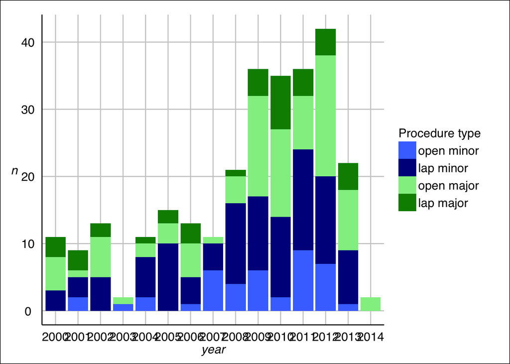

```r
#Year-by-year histogram
new$year <- year(new$opdate)
new$year <- as.factor(new$year)
new %>% group_by(ismajor,lap,year) %>% tally() -> testgraph
testgraph %>% filter(as.character(year)>"1999") -> testgraph
ggplot(testgraph, aes(x=year, y=n, fill=interaction(lap,ismajor))) + geom_histogram(stat="identity") + scale_fill_manual(labels=c("open minor", "lap minor", "open major", "lap major"), name="Procedure type", values = c("royalblue1", "blue4","lightgreen", "green4")) + theme_gdocs()
```